# Mountain Yellow-Legged Frog Population Analysis

Kiera Matiska

1/16/2022

# Overview

In the Sierra Nevada Mountains, numerous non-native species have found their home within the ecosystem. A recent research project collected data on the non-native species that have been found within Sierra Nevada lakes and recorded their populations in different lakes by the species different life stages (e.g. EggMass, Tadpoles, SubAdult, and Adult). The species in which information was collected include *Bufo boreas*, *Bufo canorus*, *Clemmys marmorata*, *Hyla regilla*, *Rana muscosa*, *Taricha torosa*, *Thamnophis couchi*, *Thamnophis elegans*, *Thamnophis sirtalis*, and *Rana catesbeiana*. In this report, I will wrangle data to look at only the species *Rana muscosa*, commonly known as the Mountain Yellow-Legged Frog, and will create two visualizations; the first one will look at the frog population throughout three life stages over 8 years while the second will look at the top five lakes with the largest Yellow-Legged Frog population over the 8 years.

```r
knitr::opts_chunk$set(echo = TRUE, warning = FALSE, message = FALSE)

# attach packages
library(tidyverse)
library(here)
library(cowplot)
library(lubridate)
library(paletteer)
```

## Read in data

```r
amphibians <- read_csv(here("data", "sierra_amphibians.csv")) # read in the csv file
```

## Wrangle data for, and create, the first visualization

On a column graph, the graph will plot:

- year on the x-axis
- number of individuals on the y-axis
- with column distinctions of life stage

```r
# change survey_date column to a value with only the year
amphibians_date <- amphibians %>% # identify data set
  mutate(survey_date = year(mdy(survey_date))) # column calls only year

# Create data subset
amphibians_subset <- amphibians_date %>% # identify data set
  select(survey_date, amphibian_species, amphibian_life_stage, amphibian_number) %>% # Only select certain columns
  filter(amphibian_species == "RAMU", # filter inputs in amphibian_species
         amphibian_life_stage != "EggMass") # filter inputs in amphibian_life_stage

# create new data set with species name spelled out
amphibians_ramu <- amphibians_subset %>% # identify data set
  mutate(amphibian_species = case_when( # rename aphibian_species inputs
    amphibian_species == "RAMU" ~ "Rana muscosa"
  ))

# create a summary table to find counts of Rana muscosa by year and life stage
ramu_summary <- amphibians_ramu %>% # create a summary table
  group_by(survey_date, amphibian_life_stage) %>%
  summarize(count = sum(amphibian_number)) # count number of individuals by year and life stage
```

```r
# create a visualizing plotting year and life stage against number of individuals
p1 <- ggplot(data = ramu_summary, # name visualization, call function, and identify data
       aes(x = survey_date, y = count)) + # set x and y parameters
  geom_col(aes(fill = amphibian_life_stage), color = "darkolivegreen4") + # define a column graph and change plot colors
  scale_fill_paletteer_d("ggthemes::excel_Green") + # use paletter package to change plot colors
  labs(title = "Mountain Yellow-Legged Frog Counts \nAmong Life Stages - 1995-2002", # add a title
       x = "Year", # change x-axis label
       y = "Number of Individuals", # change y-axis label
       fill = "Life Stage") + # change legend header
  theme(plot.title = element_text(hjust = 0.5, size = unit(12, "mm")), # center and resize title text
        plot.background = element_rect(fill = "aliceblue"), # color background of plot
        panel.background = element_rect(fill = "gray95"), # color background of panel
        legend.key.size = unit(4, "mm"), # change legend size
        legend.title = element_text(size = unit(10, "mm")), # change legend title size
        legend.text = element_text(size = unit(7, "mm")), # change legend text size
        axis.title = element_text(size = unit(10, "mm"))) # resize axis text
```

## Wrangle data for, and create, the second visualization

Using a column graph, the graph will plot:

- the five lakes with the most abundant populations of Mountain Yellow-Legged Frog (*Rana muscosa*)
- lake id on the x-axis
- number of individuals on the y-axis

```r
# create a new baseline subset for this second visualization
amphibians_subset1 <- amphibians_date %>% # make a new subset
  select(lake_id, survey_date, amphibian_species, amphibian_life_stage, amphibian_number) %>% # choose these columns
  filter(amphibian_species == "RAMU", # filter inputs in amphibian_species
         amphibian_life_stage %in% c("Adult", "SubAdult")) %>% # filter inputs in amphibian_life_stage
  mutate(lake_id = as.character(lake_id)) # change lake_id to a character

# make a new summary table with amphibian total counts among lake IDs
ramu_summary1 <- amphibians_subset1 %>% # make a new summary table
  group_by(lake_id) %>% # use lake_id as the grouping variable
  summarize(total_lake_counts = sum(amphibian_number)) # sum the number of total amphibian individuals

# make and finalize a new subset that will be used for a graph
amphibian_ramu_lake <- ramu_summary1 %>% # create the new subset
  arrange(desc(total_lake_counts)) %>% # organize counts from most to smallest
  slice(1:5) %>% # only keep the lakes with the top 5 counts
  mutate(lake_id = case_when( # rename lake_id inputs
    lake_id == "50183" ~ "Lake 50183",
    lake_id == "10223" ~ "Lake 10223",
    lake_id == "10329" ~ "Lake 10329",
    lake_id == "20196" ~ "Lake 20196",
    lake_id == "10225" ~ "Lake 10225"
  ))
```

```r
# create a plot visualizing the top 5 most RAMU populated lakes
p2 <- ggplot(data = amphibian_ramu_lake, # name visualization, call function, and identify data
       aes(x = reorder(lake_id, -total_lake_counts), y = total_lake_counts)) + # set x and y parameters
  geom_col(fill = "darkolivegreen3", color = "darkolivegreen4") + # change plot colors
  labs(title = "Most Populous Lakes with Mountain \nYellow-Legged Frog - 1995-2002", # add a title
       x = "Lake ID", # rename x-axis
       y = "Number of Individuals") + # rename y-axis
  theme(plot.title = element_text(hjust = 0.5, size = unit(12, "mm")), # change position and size of title text
        plot.background = element_rect(fill = "aliceblue"), # adjust plot color
        panel.background = element_rect(fill = "gray95"), # adjust panel color
        axis.text.x = element_text(angle = 35), # angle x-axis text
        axis.title = element_text(size = unit(10, "mm"))) # change size of axis titles
```

## Data Visualizations

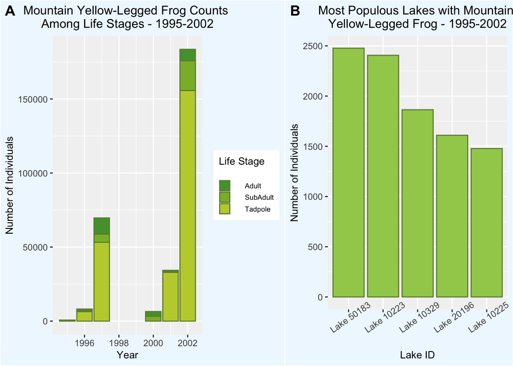

```r
# Add visualizations into a single compound
plot_grid(p1, # call function and identify visualization 1
          p2, # identify visualization 2
          labels = c("A", "B"), # label the two graphs
          rel_widths = 5:3) # resize the plots
```

**Figure 1.** (A) Mountain Yellow-Legged Frog Counts Among Life Stages from 1995-2002. Population of the Yellow-Legged Frog is shown at different life stages (Tadpole, SubAdult, and Adult) over 8 years. No data was collected for this species in 1998 or 1999. (B) Most Populous Lakes with Mountain Yellow-Legged Frogs from 1995 - 2002. Top five lakes were generates and given an ID to keep them anonymous. Between the five lakes, an average of 1,967 individuals of Mountain Yellow-Legged Frogs were found.

#### Data Citation

Knapp, R.A., C. Pavelka, E.E. Hegeman, and T.C. Smith. 2020. The Sierra Lakes Inventory Project: Non-Native fish and community composition of lakes and ponds in the Sierra Nevada, California ver 2. Environmental Data Initiative. https://doi.org/10.6073/pasta/d835832d7fd00d9e4466e44eea87fab3